# Practice some statistics with spotify data

me

2024-10-04

# Data overview and cleaning

```r
raw_data <- read_streaming_history(SPOTIFY_DATA_DIR)
dim(raw_data)
```

```
## [1] 23054     4
```

```r
print(head(raw_data, 4), row.names = FALSE)
```

```
##              endTime    artistName             trackName msPlayed
##  2021-04-28 19:30:00 The Cool Kids           Running Man    15396
##  2021-04-29 06:18:00        MGAZRD                Anyone   269008
##  2021-04-29 06:21:00          Prof           Squad Goals   200920
##  2021-04-29 06:25:00        Mihali Strongest of Our Kind   238733
```

I want to investigate fitting a Poisson distribution to the count of songs played per day. Some data transformations to support this are:

- Calculate seconds played
- Create date and hour from date time
- Filter to between 10 min and 20 sec plays
  - Considering under 20 sec to be a “skip”
  - Considering over 10 min to be a podcast (sorry grateful dead and ping ponging pigeons)

```r
listening_22 <- raw_data |>
  mutate(secPlayed = msPlayed / 1000) |>
  mutate(date = as.Date(endTime)) |>
  mutate(hour = hour(endTime)) |>
  # (20 secs, 10 min) arbitrary range for a "song" to be "listened" to
  filter(secPlayed < 10 * 60) |>
  filter(secPlayed > 20) |>
  dplyr::select(-msPlayed, -endTime)

dim(listening_22)
```

```
## [1] 19587     5
```

```r
print(head(listening_22, 4), row.names = FALSE)
```

```
##  artistName             trackName secPlayed       date hour
##      MGAZRD                Anyone   269.008 2021-04-29    6
##        Prof           Squad Goals   200.920 2021-04-29    6
##      Mihali Strongest of Our Kind   238.733 2021-04-29    6
##   The Motet             Supernova   394.000 2021-04-29    6
```

None of the analysis focuses on the duration of a song listen, but good to see nothing too too crazy in this picture.

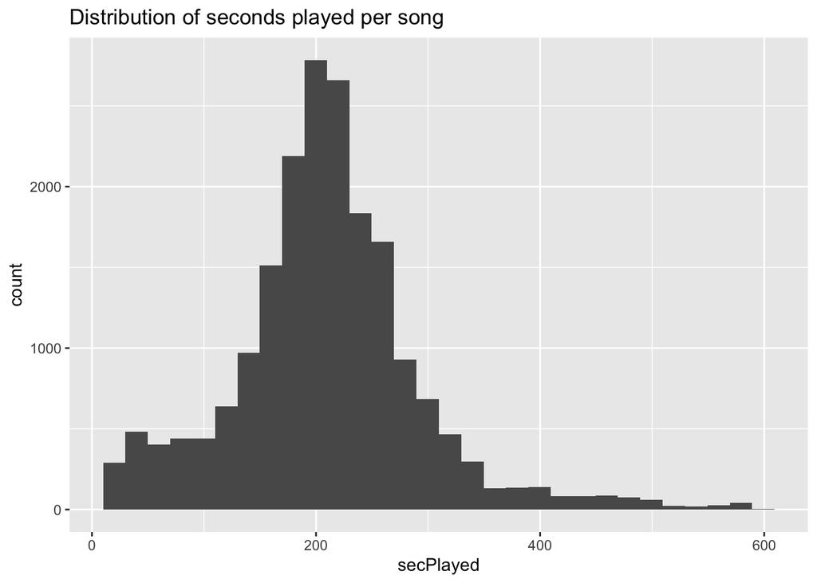

```r
ggplot(listening_22, aes(x = secPlayed)) +
  geom_histogram() +
  labs(title = "Distribution of seconds played per song")
```

```r
full_date_range <- data.frame(
  date = seq(
    from = min(listening_22$date),
    to = max(listening_22$date),
    by = "1 day"
  )
)

songs_by_day <- listening_22 |>
  group_by(date) |>
  summarise(n_songs_played = n()) |>
  right_join(full_date_range) |>
  arrange(date) |>
  replace_na(list(n_songs_played = 0))
```

The main focus so far is looking at songs played per day. Here’s a couple different views of that data.

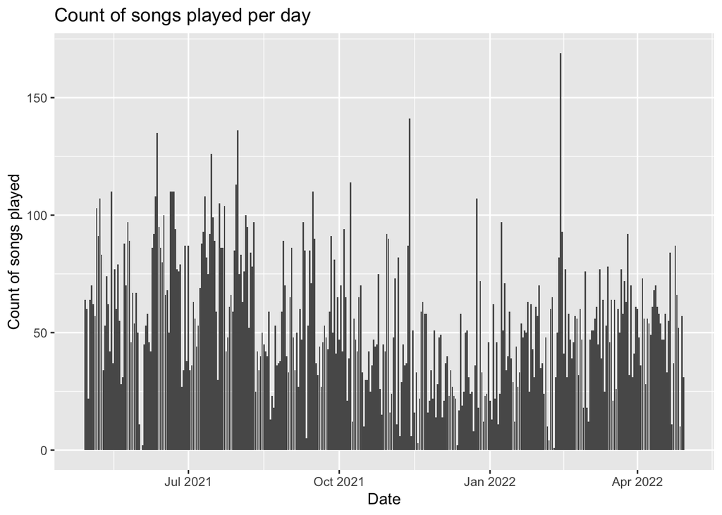

```r
ggplot(songs_by_day, aes(x = date, y = n_songs_played)) +
  geom_bar(stat = "identity") +
  labs(
    title = "Count of songs played per day",
    x = "Date",
    y = "Count of songs played"
  )
```

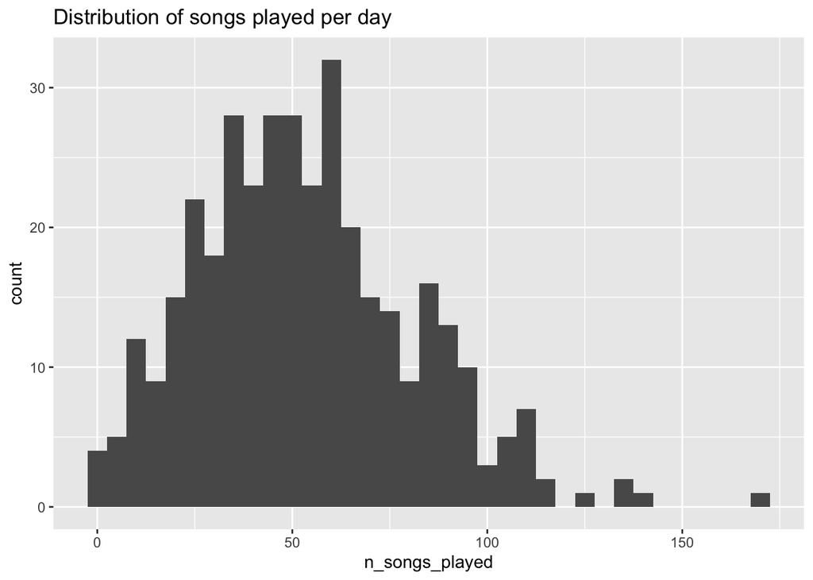

```r
ggplot(songs_by_day, aes(x = n_songs_played)) +
  geom_histogram(binwidth = 5) +
  labs(title = "Distribution of songs played per day")
```

# Estimate overall rate

## Maximum Likelihood Estimation

Poisson PMF

$$P(X = x) = \frac{\lambda^x e^{-\lambda}}{x!}$$

Likelihood

$$L(\lambda) = \prod_{i=1}^n{\frac{\lambda^{x_i} e^{-\lambda}}{x_i!}}$$

Log-likelihood for easier math with sums

$$\ln L(\lambda) = \sum_{i=1}^n{x_i \ln \lambda - \lambda - \ln{x_i!}}$$

To find the MLE take derivative and set equal to zero

$$\frac{d}{d \lambda} \ln L(\lambda) = \sum_{i = 1}^n \frac{x_i}{\lambda}
- 1 = 0$$

Solve for $\lambda$

$$\hat{\lambda} = \frac{1}{n} \sum_{i = 1}^n x_i$$

Applying we get the average songs per day to be:

```r
x <- songs_by_day$n_songs_played
n <- length(x)
mle_lambda <- sum(x) / n

mle_lambda
```

```
## [1] 53.51639
```

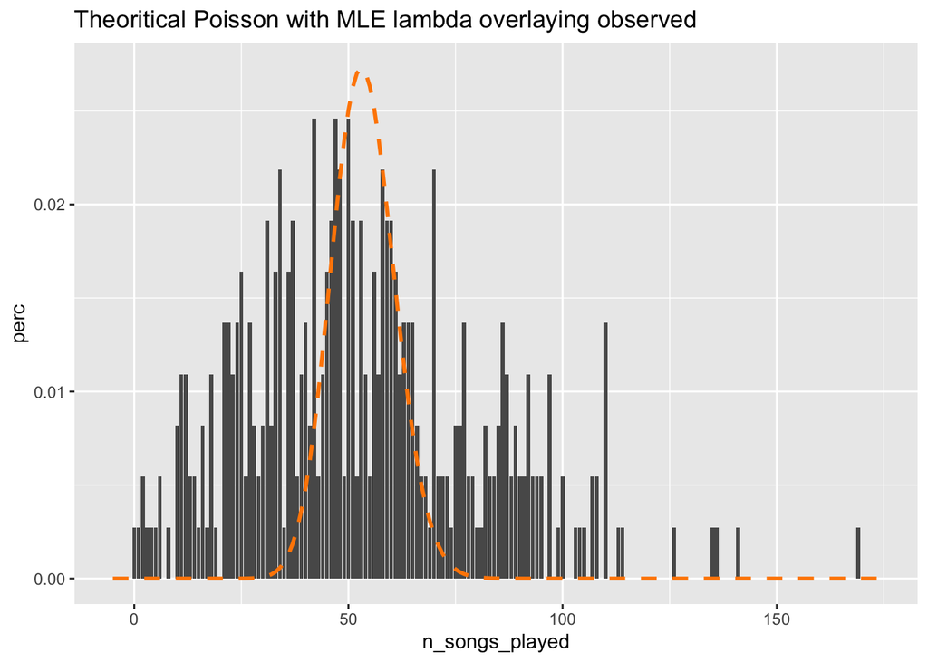

```r
x_range <- seq(from = -5, to = round(max(x)) + 5, by = 1)
mle_density <- data.frame(x = x_range, y = dpois(x_range, mle_lambda))

songs_by_day |>
  group_by(n_songs_played) |>
  summarise(perc = n() / nrow(songs_by_day)) |>
  ggplot(aes(x = n_songs_played, y = perc)) +
  geom_bar(stat = "identity") +
  geom_line(
    data = mle_density,
    aes(x, y * 0.5),
    linetype = "dashed",
    color = "#ff8800",
    linewidth = 1
  ) +
  labs(
    title = "Theoritical Poisson with MLE lambda overlaying observed"
  )
```

## Estimate with Bayes

Using an uninformative $Gamma$ distributed prior (good brief explanation from [stackexchange](https://math.stackexchange.com/a/456050/464500))

> The distribution $Gamma(\alpha=0.001,\beta=0.001)$ does indeed have most of its mass very close to 0, but it also has an impressive tail, so in fact its mean is $1$. This observation, however, is unrelated to its vagueness. It is *vague* in the sense that as soon as you update it based on your first empirical observation, the posterior distribution will tell you that whatever data point you observed is a very typical one. Put another way, it reflects a belief that is very weakly held and easily molded by exposure to new information.

> Let’s say that you’re trying to estimate the average number of calls that come into a call center per hour, modeled as a Poisson distribution with rate $\lambda$. $Gamma(\alpha=0.001,\beta=0.001)$ reflects your prior belief about the value of $\lambda$. In your first hour of observation, $50$ calls come in, so you perform a Bayesian update and derive $Gamma(\alpha=50.001, \beta=1.001)$ as your posterior. This posterior distribution has a mean of $\frac{50.001}{1.001} \approx 50$. So, now that you have actual data, you’ve almost completely thrown away your old prejudices and updated your beliefs to match your empirical observations.

> It’s quite common to use $Gamma(\alpha=0,\beta=0)$ as a prior. That distribution doesn’t even make mathematical sense: its PDF contains the term $0^0$ and regardless whether you decide that $0^0=0$ or $0^0=1$, the total area under the distribution curve will come out to $0$ or $\infty$ respectively: not $1$. Nonetheless, that doesn’t stop us from using it as a prior: we’ll get a sensible posterior as soon as we observe our first data point. A prior of this sort is called an *improper* prior. Some authors use $improper$ and $vague$ interchangeably.

Poisson PMF

$$P(X = x) = \frac{\lambda^x e^{-\lambda}}{x!}$$

Likelihood

$$L(x_i | \lambda) = \prod_{i=1}^n{\frac{\lambda^{x_i}
e^{-\lambda}}{x_i!}}$$

In Bayes we’ll work with something proportional to the likelihood instead of likelihood itself (makes life easier and works out to same results).

$$L(x_i | \lambda) \propto \prod_{i=1}^n{\lambda^{x_i} e^{-\lambda}}$$

The prior distribution of $Gamma(\alpha, \beta)$ has PDF

$$Gamma(\alpha, \beta) = \frac{\beta ^ \alpha}{ \Gamma(\alpha)}
x^{\alpha-1} e^{-\beta x}$$

The posterior is the product of these

$$\pi(\lambda) \propto \prod_{i=1}^n{\lambda^{x_i} e^{-\lambda}} \times
\frac{\beta ^ \alpha}{ \Gamma(\alpha)} \lambda^{\alpha-1} e^{-\beta
\lambda}$$
Drop out $\frac{\beta ^ \alpha}{ \Gamma(\alpha)}$; scalar as far as $\lambda$ is concerned.

$$\pi(\lambda) \propto \prod_{i=1}^n{\lambda^{x_i} e^{-\lambda}}
\times \lambda^{\alpha-1} e^{-\beta \lambda}$$
Simplify

$$\pi(\lambda) \propto \lambda^{\sum{x_i}} e^{-n\lambda}
\times \lambda^{\alpha-1} e^{-\beta \lambda}$$

Further simplify

$$\pi(\lambda) \propto \lambda^{(\alpha + \sum{x_i}) - 1} e^{-(\beta + n)
\lambda}$$

This turns out to be $Gamma(\alpha + \sum{x_i}, \beta + n)$. In other words given the data you can calculate the posterior dist as gamma with:

$$\alpha_{post} = \alpha_{prior} + \sum{x_i} \quad;\quad \beta_{post} =
\beta_{prior} + n$$
Applying this we get

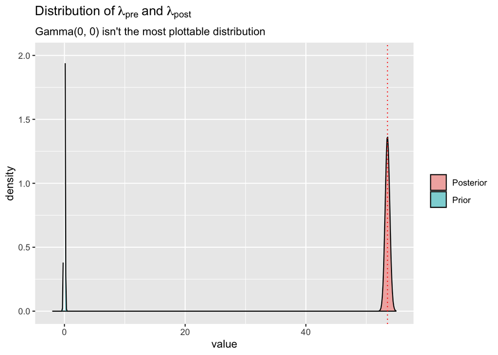

```r
x <- songs_by_day$n_songs_played
n <- length(x)

# Gamma(0, 0)
prior_alpha <- 0
prior_beta <- 0

# Gamma(alpha + sum(x), beta + n)
posterior_alpha <- prior_alpha + sum(x)
posterior_beta <- prior_beta + n

n_samples <- 1e5
prior_post_samples <- data.frame(
  Prior = rgamma(n_samples, prior_alpha, prior_beta),
  Posterior = rgamma(n_samples, posterior_alpha, posterior_beta)
) |>
  pivot_longer(everything())

ggplot(prior_post_samples, aes(x = value, fill = name)) +
  geom_density(alpha = 0.5) +
  geom_vline(xintercept = prior_alpha / prior_beta, linetype = "dotted", color = "blue") +
  geom_vline(xintercept = posterior_alpha / posterior_beta, linetype = "dotted", color = "red") +
  labs(
    title = bquote(
      "Distribution of" ~ lambda[pre] ~ "and" ~ lambda[post]
    ),
    subtitle = "Gamma(0, 0) isn't the most plottable distribution",
    fill = ""
  ) +
  lims(x = c(-2, 55), y = c(0, 2))
```

Or just viewing the posterior

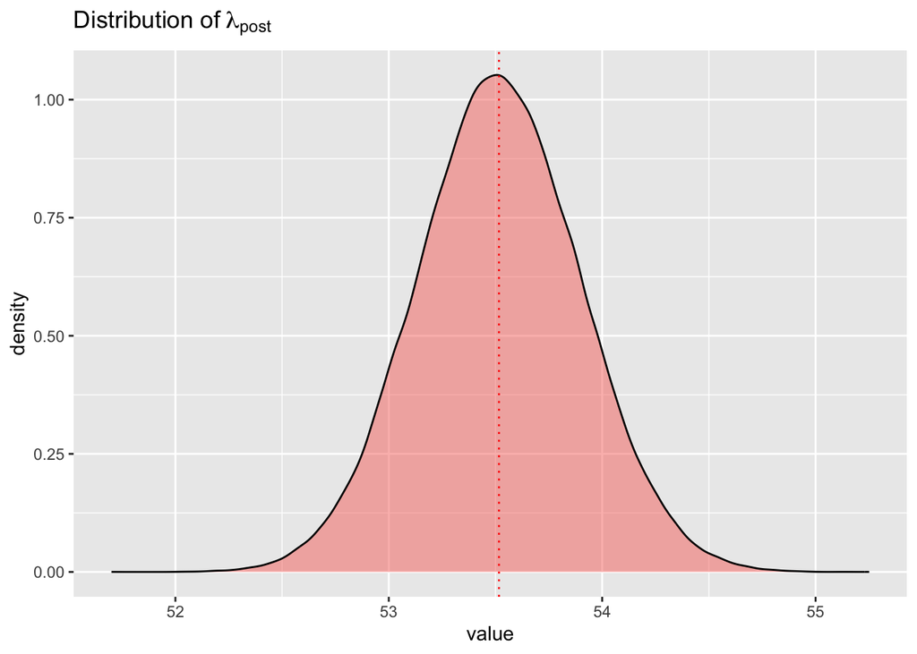

```r
prior_post_samples |>
  filter(name == "Posterior") |>
  ggplot(aes(x = value)) +
  geom_density(alpha = 0.5, fill = "#F8766D") +
  geom_vline(xintercept = posterior_alpha / posterior_beta, linetype = "dotted", color = "red") +
  labs(
    title = bquote(
      "Distribution of" ~ lambda[post]
    ),
    fill = ""
  )
```

It is worth noting that if estimating Poisson $\lambda$ using a $Gamma(0, 0)$ prior and updating with $Gamma(\alpha + \sum{x_i}, \beta + n)$ then the expected value ( $\mathbb{E}[Gamma(\alpha, \beta)] = \frac{\alpha}{\beta}$ or in this case $\mathbb{E}[Gamma(0 + \sum{x_i}, 0 + n)] = \frac{\sum{x_i}}{n} = \frac{1}{n} \sum{x_i}$ ) is exactly equal to the MLE estimator ($\frac{1}{n} \sum{x_i}$ ).

For that reason, there’s not a overlaying the theoretical density on observed data and no further comparison.

## Fisher information of $\lambda$ in Poisson

Doesn’t really relate as much to overall idea, but just something to practice.

The Fisher information in general is represented as:

$$I(\lambda) = \mathbb{E}\left[\left(\frac{d}{d\lambda} \ln
L(\lambda)\right)^2\right] =
-\mathbb{E}\left[\left(\frac{d^2}{d\lambda^2} \ln L( \lambda)
\right)\right]$$

Poisson log likelihood is

$$\ln L(\lambda) = \sum_{i=1}^n{x_i \ln \lambda - \lambda - \ln{x_i!}}$$

First derivative of the log likelihood

$$\frac{d}{d\lambda} \ln L(\lambda) = \sum_{i=1}^n{\frac{x_i}{\lambda} -
1} = -n + \frac{1}{\lambda} \sum{x_i}$$

Second derivative of the log likelihood

$$\frac{d^2}{d\lambda^2} \ln L(\lambda) = -\frac{1}{\lambda^2} \sum{x_i}$$

Plugging into the fisher information formula

$$I(\lambda) = \mathbb{E}\left[\left(-n +
\frac{1}{\lambda}\sum{x_i}\right)^2\right] =
-\mathbb{E}\left[\left(-\frac{1}{\lambda^2} \sum{x_i}\right)\right]$$

Working with the second derivative view seems nicer. Pull out the $\frac{1}{\lambda^2}$; just a scalar to the sum.

$$I(\lambda) = \frac{1}{\lambda^2} \mathbb{E}\left[\sum{x_i}\right]$$

Expectation of sum is equal to sum of expectations. Expected value of Poisson is $\lambda$. Simplify.

$$I(\lambda) = \frac{1}{\lambda^2}\sum{\mathbb{E}[x_i]} =
\frac{1}{\lambda^2}\sum{\lambda} = \frac{n\lambda}{\lambda^2}$$

Further simplified. Here is our Fisher information for Poisson rate parameter $\lambda$.

$$I(\lambda) = \frac{n}{\lambda}$$

Intuitive explanation of the fisher information.

- $n$ the more observations the higher the information
- $\frac{1}{\lambda}$ higer rates will lower our information
  - e.g.: If you have $n=50$ and the average rate is $\lambda=1$ per day then you have a lot of information about the process; but if you have $n=50$ and the average rate is $\lambda=100$ per day then you don’t have much information

Fisher information for our data with estimated $\lambda \approx 53.52$ and $n = 366$

```r
366 / 53.52
```

```
## [1] 6.838565
```

# Detecting a change point

## Exhaustive search

Was there a change in this listening rate?

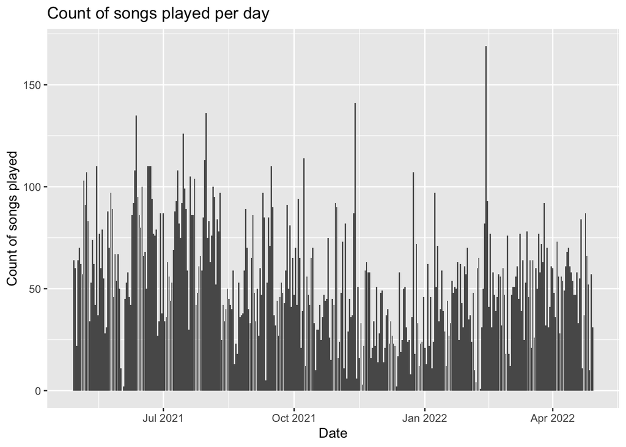

```r
ggplot(songs_by_day, aes(x = date, y = n_songs_played)) +
  geom_bar(stat = "identity") +
  labs(
    title = "Count of songs played per day",
    x = "Date",
    y = "Count of songs played"
  )
```

Going to model 3 parameters:

- $\tau$ - the change point (i.e. if there was a change at the 120th day of the year $\tau = 120$)
  - Uniform prior $\tau_{prior} \sim \operatorname{DiscreteUniform}(1, 365)$
- $\lambda_1$ - the rate parameter for a poisson distribution of my listening *before* $\tau$
  - Uninformative Gamma prior $\lambda_{1prior} \sim \operatorname{Gamma(0, 0)}$
- $\lambda_2$ - the rate parameter for a poisson distribution of my listening *after* $\tau$
  - Uninformative Gamma prior $\lambda_{2prior} \sim \operatorname{Gamma(0, 0)}$

Posterior distributions

Using $Gamma(\alpha_\text{prior}, \beta_\text{prior})$ as prior for a Poisson rate parameter we can update to posterior using $Gamma(\alpha_\text{prior} + \sum x_i, \beta_\text{prior} + n)$.

If using $Gamma(0, 0)$ as the prior this simplifies to $Gamma(\sum x_i, n)$ with $\mathbb{E}[Gamma(\sum x_i, n)] = \frac{\sum x_i}{n}$

For a given value of $\tau$

- $\lambda_{1posterior} \sim Gamma(\sum{x_{1i}}, n_1) = Gamma(\sum{x_{1i}}, \tau)$
  - $x1$ denotes all $x$ before $\tau$
  - $\mathbb{E}[\lambda_{1posterior}] = \frac{\sum x_{1i}}{n_1} = \frac{\sum x_{1i}}{\tau}$
  - $L(x_{1i} | \lambda_{1}) \propto \prod_{i=1}^{n_1}{\lambda_1^{x_{1i}} e^{-\lambda_{1}}}$
- $\lambda_{2posterior} \sim Gamma(\sum{x_{2i}}, n_2) = Gamma(\sum{x_{2i}}, n - \tau)$
  - $x2$ denotes all $x$ after $\tau$
  - $\mathbb{E}[\lambda_{2posterior}] = \frac{\sum x_{2i}}{n_2} = \frac{\sum x_{2i}}{n - \tau}$
  - $L(x_{2i} | \lambda_2) \propto \prod_{i=1}^{n_2}{\lambda_2^{x_{2i}} e^{-\lambda_{2}}}$

All of that leads to

$$L(\tau) \propto \prod_{i=1}^{n_1}{\lambda_1^{x_{1i}} e^{-\lambda_1}}
\times \prod_{i=1}^{n_2}{\lambda_2^{x_{2i}} e^{-\lambda_2}}$$

```r
# defaults to MLE lambda if not provided
pois_likelihood_propto <- function(x, lambda = sum(x) / length(x)) {
  L <- 1
  for (xi in x) {
    Li <- (lambda^xi * exp(-lambda))
    L <- L * Li
  }

  return(L)
}

posterior_tau <- function(x, tau) {
  # ASSUMES X IS SORTED BY DATE!!
  n <- length(x)

  if (tau == 0 | tau == n) {
    return(0)
  }

  x1 <- x[1:tau]
  n1 <- length(x1)

  x2 <- x[(tau + 1):n]
  n2 <- length(x2)

  lambda1 <- sum(x1) / n1
  lambda2 <- sum(x2) / n2

  x1_likelihood <- pois_likelihood_propto(x1, lambda1)
  x2_likelihood <- pois_likelihood_propto(x2, lambda2)

  x1_likelihood * x2_likelihood
}
```

Implementing this leads to an example of a practical computing reason we prefer log likelihoods…

```r
x <- songs_by_day$n_songs_played
tau_dist <- vapply(seq_along(x), \(tau) posterior_tau(x, tau), numeric(1))

head(tau_dist)
```

```
## [1] Inf Inf Inf Inf Inf Inf
```

Convert to be log likelihood

$$\ln L(\lambda) = \sum_{i=1}^n{x_i \ln \lambda - \lambda - \ln{x_i!}}$$

and this leads to

$$L(\tau) = \sum_{i=1}^{n_1}{x_{1i} \ln \lambda_1 - \lambda_1 -
\ln{x_{1i}!}} + \sum_{i=1}^{n_2}{x_{2i} \ln \lambda_2 - \lambda_2 -
\ln{x_{2i}!}}$$

For implementation instead of `log(factorial(x))`, I’ll use `lgamma(x + 1)` (log gamma function for generalized factorial; more numerically stable).

```r
# defaults to MLE lambda if not provided
pois_log_likelihood <- function(x, lambda = sum(x) / length(x)) {
  sum(x * log(lambda) - lambda - lgamma(x + 1))
}

posterior_tau <- function(x, tau) {
  # ASSUMES X IS SORTED BY DATE!!
  n <- length(x)

  if (tau == 0 | tau == n) {
    return(-Inf)
  }

  x1 <- x[1:tau]
  n1 <- length(x1)

  x2 <- x[(tau + 1):n]
  n2 <- length(x2)

  lambda1 <- sum(x1) / n1
  lambda2 <- sum(x2) / n2

  x1_log_likelihood <- pois_log_likelihood(x1, lambda1)
  x2_log_likelihood <- pois_log_likelihood(x2, lambda2)

  x1_log_likelihood + x2_log_likelihood
}
```

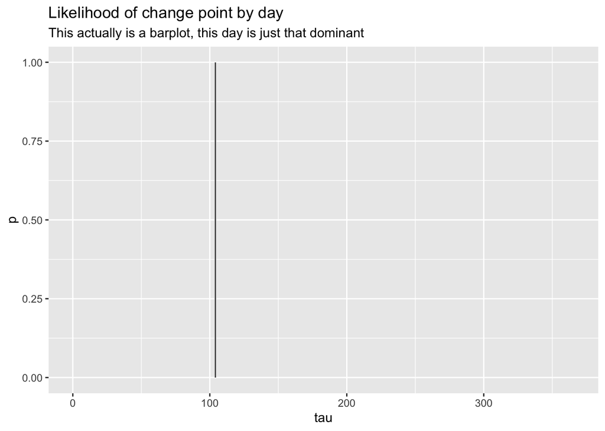

```r
x <- songs_by_day$n_songs_played
n <- length(x)
tau_choices <- 1:(n - 1)
log_tau_dist <- vapply(tau_choices, \(tau_i) posterior_tau(x, tau_i), numeric(1))

# exponentiate and normalize
tau_post_probs <- exp(log_tau_dist - max(log_tau_dist))
tau_post_probs <- tau_post_probs / sum(tau_post_probs)

# most likely changepoint
day_num <- which.max(tau_post_probs)
date <- songs_by_day$date[day_num]

posterior <- data.frame(tau = tau_choices, p = tau_post_probs)

ggplot(posterior, aes(x = tau, y = p)) +
  geom_bar(stat = "identity") +
  labs(
    title = "Likelihood of change point by day",
    subtitle = "This actually is a barplot, this day is just that dominant"
  )
```

It turns out only a handful values of tau have non-zero likelihood if rounded to 15 decimals.

```r
options(scipen = 999)

posterior |>
  mutate(p = round(p, 15)) |>
  filter(p > 0) |>
  print(row.names = FALSE)
```

```
##  tau                 p
##  100 0.000000000000005
##  102 0.000000000018627
##  103 0.000000075081962
##  104 0.999998918139517
##  105 0.000001005280583
##  106 0.000000001479212
##  107 0.000000000000094
```

```r
options(scipen = 0)
```

Comparing distributions before and after most likely changepoint

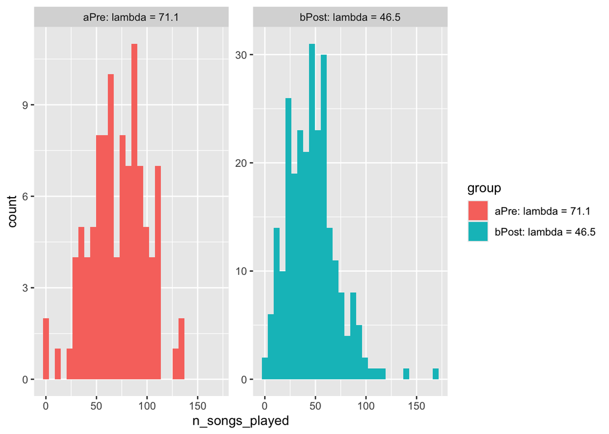

```r
songs_by_day <- songs_by_day |>
  mutate(group = ifelse(row_number() <= day_num, "aPre", "bPost")) |>
  group_by(group) |>
  mutate(lambda = sum(n_songs_played) / length(n_songs_played)) |>
  ungroup() |>
  mutate(group = sprintf("%s: lambda = %.1f", group, lambda))

ggplot(songs_by_day, aes(x = n_songs_played, fill = group)) +
  facet_wrap(~group, scales = "free_y") +
  geom_histogram()
```

In context of original data with rate param plotted before and after change.

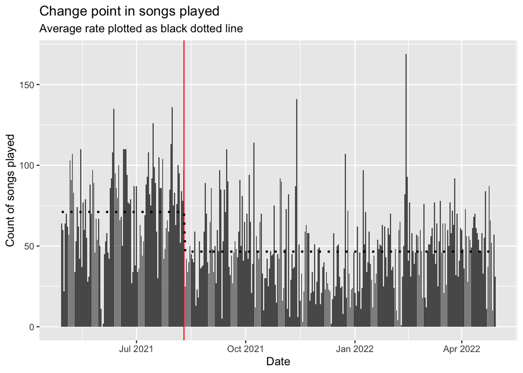

```r
ggplot(songs_by_day, aes(x = date, y = n_songs_played)) +
  geom_bar(stat = "identity") +
  geom_vline(xintercept = date, color = "#FF0000") +
  geom_line(aes(y = lambda), linetype = "dotted", linewidth = 1) +
  labs(
    x = "Date", y = "Count of songs played",
    title = "Change point in songs played",
    subtitle = "Average rate plotted as black dotted line"
  )
```

## Is a change point view better than 1 $\lambda$?

### Bayes Factor

Kinda just likelihood ratio since I didn’t have any prior beliefs baked into the gamma.

$$\text{Bayes Factor} = \frac{P(\text{data} \mid M_1)}{P(\text{data} \mid
M_2)}$$

In this case:

$$\text{Bayes Factor} = \frac{P(x_1 | \lambda_1) \times P(x_2 |
\lambda_2)}{P(x | \lambda)}$$

For computation easier to use log likelihoods

$$\text{Bayes Factor} = e^{\ln P(x_1 | \lambda_1)) + \ln P(x_2 |
\lambda_2) - \ln P(x | \lambda)}$$

The ratio $>>>1$ says that the change point model is better.

```r
x <- songs_by_day$n_songs_played
n <- length(x)
x1 <- x[1:day_num]
x2 <- x[(day_num + 1):n]

exp(pois_log_likelihood(x1) + pois_log_likelihood(x2) - pois_log_likelihood(x))
```

```
## [1] 2.891249e+172
```

Alternatively, we can exponentiate and then take the ratio.

If you go that route it’s nice to know about [log-sum-exp trick](https://gregorygundersen.com/blog/2020/02/09/log-sum-exp/) to avoid underflow issues when calculating things like $e^{-3755}$ and $e^{-3357}$ (as we’d like to do here).

```r
log_l_x <- pois_log_likelihood(x)

log_l_x1 <- pois_log_likelihood(x1)
log_l_x2 <- pois_log_likelihood(x2)
log_l_x12 <- log_l_x1 + log_l_x2

# adjust to avoid underflow R isses exp(-3754.894) is too small to compute
adj <- max(c(log_l_x, log_l_x12))

l_x <- exp(log_l_x - adj)
l_x12 <- exp(log_l_x12 - adj)

round(l_x12 / l_x)
```

```
## [1] 2.891249e+172
```

### AIC

I mean why not at this point. AIC agrees with BF that change point appears to fit better.

$$AIC = -2 \ln (L) + 2k$$

```r
k <- 1
-2 * log_l_x + 2 * k
```

```
## [1] 7511.789
```

```r
k <- 3
-2 * log_l_x12 + 2 * k
```

```
## [1] 6721.576
```

### ICOMP

Keep it going.

$$ICOMP = -2 \ln (L) + 2C_1(\hat{F}^{-1})$$

For single lambda parameter poisson process the fisher information is $1 \times 1$.

$$F = \left[ \frac{n}{\lambda} \right]$$

```r
n / mle_lambda
```

```
## [1] 6.839026
```

This means:

$$F^{-1} = \left[ \frac{\lambda}{n} \right]$$

```r
mle_lambda / n
```

```
## [1] 0.1462197
```

Calculate C1 measure; $p$ is the rank of the matrix.

$$C_1(F^{-1}) = \frac{p}{2} \ln\left( \frac{1}{p} \text{tr}(F^{-1})
\right) - \frac{1}{2} \ln\left( \det(F^{-1}) \right)$$

Given this is a $1 \times 1$ matrix we can simplify: $p=1$, $\text{tr}(F^{-1}) = F^{-1}$, $\text{det}(F^{-1}) = F^{-1}$

$$C_1(F^{-1}) = \frac{1}{2} \ln(F^{-1}) - \frac{1}{2} \ln(F^{-1}) = 0$$

Okie doke, pretty easy to calculate from there since $2C_1(\hat{F}^{-1}) = 0$ in this case.

$$ICOMP = -2 \ln (L) + 2C_1(\hat{F}^{-1}) = -2 \ln(L)$$

```r
-2 * log_l_x
```

```
## [1] 7509.789
```

to be continued…

## MCMC approach with `rstan`

To use rstan you define model in stan language. Rmd can do this via stan chunk with `output.var` parameter.

```stan
data {
  int<lower=1> N;            // number of observations (days)
  int x[N];                  // observed data (counts per day)
}

parameters {
  real<lower=1, upper=N-1> tau; // change-point
  real<lower=0> lambda1;        // Poisson rate < tau
  real<lower=0> lambda2;        // Poisson rate > tau
}

model {
  // Vague priors
  lambda1 ~ gamma(0.001, 0.001);
  lambda2 ~ gamma(0.001, 0.001);

  // Likelihood
  for (i in 1:N) {
    if (i <= tau)
      x[i] ~ poisson(lambda1);
    else
      x[i] ~ poisson(lambda2);
  }
}
```

Once defined we can sample the posterior via MCMC. I’m sampling twice with varied iterations of $2000$ and $10000$.

- Effective sample size $n_{\text{eff}} = \frac{N}{1 + 2 \sum_{t=1}^{T-1} \rho(t)}$; where $\rho(t)$ is ACF at lag $t$, and $T$ is number of iterations in chain
  - Number of independent samples that the chains are effectively providing.
  - If we have high autocorrelation we’ll have low effective sample size
  - Low effective sample size means chains aren’t exploring posterior efficiently; might run longer chains or tuned step size
- $\hat{R}$ - Potential scale reduction factor - $\hat{R} = \frac{\text{between chain variance}}{\text{within chain variance}}$
  - Compares betwee-chain variance to within-chain variance (similar line of thinking to ANOVA) large $\hat{R}$ indicate larger between chain variance and this indicates we haven’t converged
  - Rules of thumb
    - $\hat{R} \approx 1$ - converged
    - $\hat{R} > 1.1$ - lack of convergence - chains aren’t mixing or exploring the same posterior space (could be stuck in different parts of space)
      - Tuning steps to help: increase iterations, adjust step size, adjust treedepth
      - Theory steps to help: reevaluate priors or model structure to ensure posterior is well-formed

A piece of the issue might be a limitation of modeling tau. Stan can’t model discrete parameters natively… :( Unlucky choice for this first experiment.

```r
fit_2000 <- sampling(
  object = changepoint_stan_model,
  data = list(N = length(x), x = x),
  iter = 2000,
  chains = 4
)

fit_10000 <- sampling(
  object = changepoint_stan_model,
  data = list(N = length(x), x = x),
  iter = 10000,
  chains = 4
)

print(fit_10000)
```

```
## Inference for Stan model: anon_model.
## 4 chains, each with iter=10000; warmup=5000; thin=1;
## post-warmup draws per chain=5000, total post-warmup draws=20000.
##
##             mean se_mean   sd     2.5%      25%      50%      75%    97.5%
## tau       104.50    0.01 0.29   104.03   104.26   104.51   104.75   104.97
## lambda1    71.12    0.02 0.82    69.51    70.56    71.13    71.69    72.71
## lambda2    46.54    0.01 0.43    45.70    46.26    46.55    46.83    47.39
## lp__    58769.31    0.02 1.01 58766.57 58768.92 58769.62 58770.03 58770.30
##         n_eff Rhat
## tau      2110    1
## lambda1  1742    1
## lambda2  1530    1
## lp__     2227    1
##
## Samples were drawn using NUTS(diag_e) at Fri Oct  4 10:20:33 2024.
## For each parameter, n_eff is a crude measure of effective sample size,
## and Rhat is the potential scale reduction factor on split chains (at
## convergence, Rhat=1).
```

```r
samples_mcmc_2000 <- extract(fit_2000) |>
  as.data.frame() |>
  select(-lp__)

samples_mcmc_10000 <- extract(fit_10000) |>
  as.data.frame() |>
  select(-lp__)

samples_mcmc_long <- samples_mcmc_10000 |>
  mutate(chain = rep(1:4, each = 5000)) |>
  pivot_longer(-chain) |>
  mutate(mcmc_iter = 10000) |>
  bind_rows(
    samples_mcmc_2000 |>
      mutate(chain = rep(1:4, each = 1000)) |>
      pivot_longer(-chain) |>
      mutate(mcmc_iter = 2000)
  ) |>
  mutate(mcmc_iter = factor(paste("MCMC iter =", mcmc_iter))) |>
  mutate(chain = factor(chain))
```

And then we can plot the posteriors for the 3 parameters.

The table shows the count of samples rounded to nearest integer day (remember Stan can’t model discrete parameter). From the more manual approach with fixed MLE lambda’s the day nominated as most likely change point was $104$. Here we see some agreement with a change at $104$ or $105$, but potential evidence of a change at $163$ or $164$.

```r
samples_mcmc_long |>
  filter(name == "tau") |>
  mutate(value = round(value)) |>
  group_by(value, mcmc_iter) |>
  summarise(count = n()) |>
  arrange(mcmc_iter, value) |>
  select(mcmc_iter, value, count)
```

```
## # A tibble: 6 × 3
## # Groups:   value [4]
##   mcmc_iter         value count
##   <fct>             <dbl> <int>
## 1 MCMC iter = 10000   104  9880
## 2 MCMC iter = 10000   105 10120
## 3 MCMC iter = 2000    104  1529
## 4 MCMC iter = 2000    105  1471
## 5 MCMC iter = 2000    163   455
## 6 MCMC iter = 2000    164   545
```

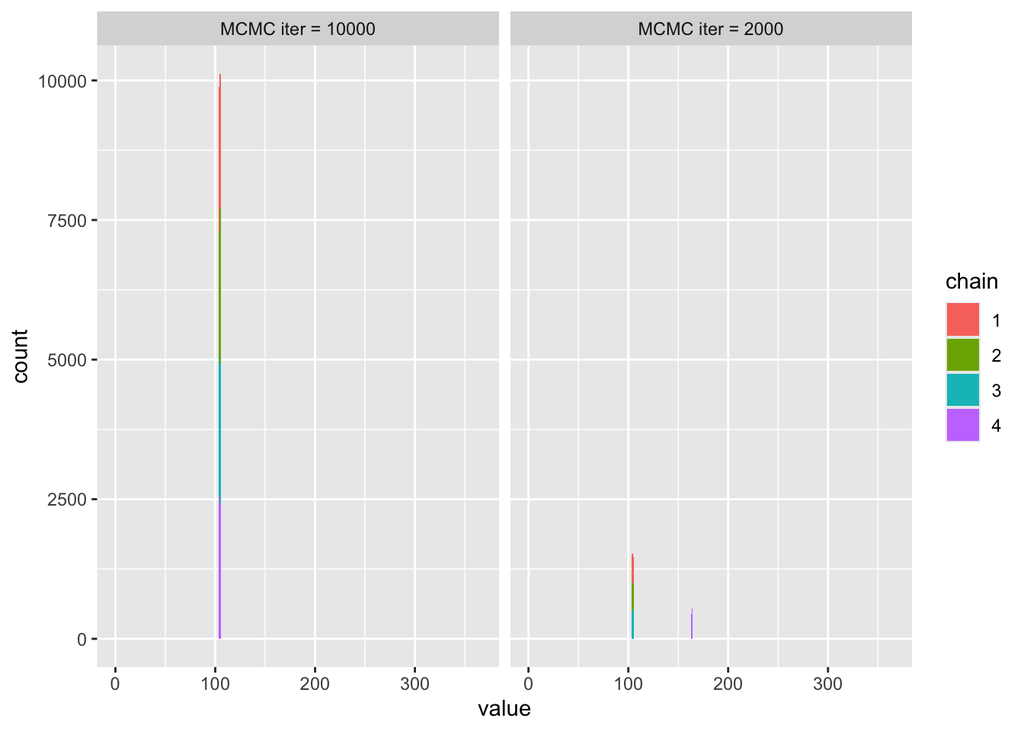

```r
samples_mcmc_long |>
  filter(name == "tau") |>
  ggplot(aes(x = value, fill = chain)) +
  facet_wrap(~ mcmc_iter) +
  geom_histogram(binwidth = 1) +
  xlim(0, 366)
```

Bi-modal distributions that seem to relate to the two different options for change-points; feels like we’re modeling 2 separate change points with a pair of lambdas each.

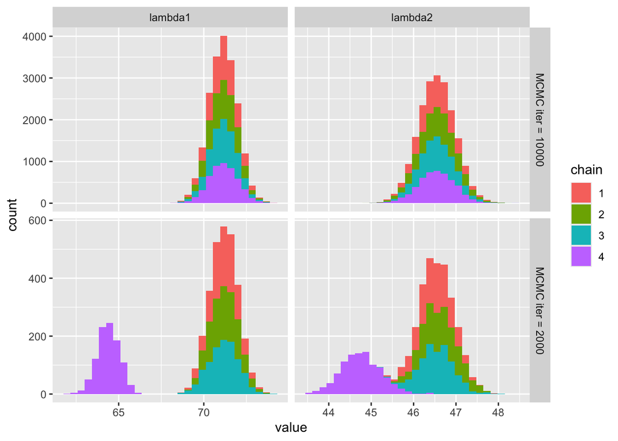

```r
samples_mcmc_long |>
  filter(name != "tau") |>
  ggplot(aes(x = value, fill = chain)) +
  facet_grid(mcmc_iter ~ name, scales = "free") +
  geom_histogram()
```

One of two things happened

1. The lack of convergence (indicated by low effective sample size and high $\hat{R}$) means these results are meh and should be fixed before interpretting
2. The ability to sample the joint posterior distribution shows the limitations of the more manual approach where we didn’t see this bi-modal possibility. The more manual approach is fixing the lambdas at their MLE values, but the MCMC process is modeling the variability of these lambda values.

### What about… two change points with MCMC?

What’s this look like chucking in two different possible change points? Just an excuse to modify model.

```stan
data {
  int<lower=1> N;            // number of observations (days)
  int x[N];                  // observed data (counts per day)
}

parameters {
  real<lower=1, upper=N-1> tau1; // change-point 1
  real<lower=1, upper=N-1> tau2; // change-point 2
  real<lower=0> lambda1;         // Poisson rate < tau1
  real<lower=0> lambda2;         // Poisson rate > tau1 but < tau 2
  real<lower=0> lambda3;         // Poisson rate > tau2
}

model {
  // Vague priors
  lambda1 ~ gamma(0.001, 0.001);
  lambda2 ~ gamma(0.001, 0.001);
  lambda3 ~ gamma(0.001, 0.001);

  // Likelihood
  for (i in 1:N) {
    if (i <= tau1) {
      x[i] ~ poisson(lambda1);
    } else if (i <= tau2) {
      x[i] ~ poisson(lambda2);
    } else {
      x[i] ~ poisson(lambda3);
    }
  }
}
```

```r
fit2_2000 <- sampling(
  object = changepoint_stan_model2,
  data = list(N = length(x), x = x),
  iter = 2000,
  chains = 4
)

fit2_10000 <- sampling(
  object = changepoint_stan_model2,
  data = list(N = length(x), x = x),
  iter = 10000,
  chains = 4
)

print(fit2_10000)
```

```
## Inference for Stan model: anon_model.
## 4 chains, each with iter=10000; warmup=5000; thin=1;
## post-warmup draws per chain=5000, total post-warmup draws=20000.
##
##             mean se_mean    sd     2.5%      25%      50%      75%    97.5%
## tau1      157.18   37.58 53.16   104.09   104.61   152.05   204.03   222.78
## tau2      163.20   37.43 52.97   105.10   107.20   160.99   208.00   229.89
## lambda1    65.64    4.41  6.25    57.94    60.03    64.63    72.27    72.70
## lambda2    20.61    9.20 13.15     0.09    12.27    23.14    27.07    38.98
## lambda3    46.53    0.96  1.41    44.21    45.31    46.97    47.35    48.60
## lp__    58691.22   66.12 94.01 58555.49 58614.24 58697.14 58779.32 58791.10
##         n_eff   Rhat
## tau1        2 138.55
## tau2        2  28.22
## lambda1     2  14.86
## lambda2     2   6.99
## lambda3     2   4.09
## lp__        2  26.13
##
## Samples were drawn using NUTS(diag_e) at Fri Oct  4 10:24:23 2024.
## For each parameter, n_eff is a crude measure of effective sample size,
## and Rhat is the potential scale reduction factor on split chains (at
## convergence, Rhat=1).
```

```r
samples2_mcmc_2000 <- extract(fit2_2000) |>
  as.data.frame() |>
  select(-lp__)

samples2_mcmc_10000 <- extract(fit2_10000) |>
  as.data.frame() |>
  select(-lp__)

samples2_mcmc_long <- samples2_mcmc_10000 |>
  mutate(chain = rep(1:4, each = 5000)) |>
  pivot_longer(-chain) |>
  mutate(mcmc_iter = 10000) |>
  bind_rows(
    samples2_mcmc_2000 |>
      mutate(chain = rep(1:4, each = 1000)) |>
      pivot_longer(-chain) |>
      mutate(mcmc_iter = 2000)
  ) |>
  mutate(mcmc_iter = factor(paste("MCMC iter =", mcmc_iter))) |>
  mutate(chain = factor(chain))
```

```r
samples2_mcmc_long |>
  filter(name %in% c("tau1", "tau2")) |>
  mutate(value = round(value)) |>
  group_by(value, mcmc_iter) |>
  summarise(count = n()) |>
  arrange(mcmc_iter, value) |>
  select(mcmc_iter, value, count)
```

```
## # A tibble: 88 × 3
## # Groups:   value [80]
##    mcmc_iter         value count
##    <fct>             <dbl> <int>
##  1 MCMC iter = 10000   104  3020
##  2 MCMC iter = 10000   105  9503
##  3 MCMC iter = 10000   106  2366
##  4 MCMC iter = 10000   107   215
##  5 MCMC iter = 10000   108   360
##  6 MCMC iter = 10000   109   181
##  7 MCMC iter = 10000   110    21
##  8 MCMC iter = 10000   111     6
##  9 MCMC iter = 10000   112    32
## 10 MCMC iter = 10000   113    25
## # ℹ 78 more rows
```

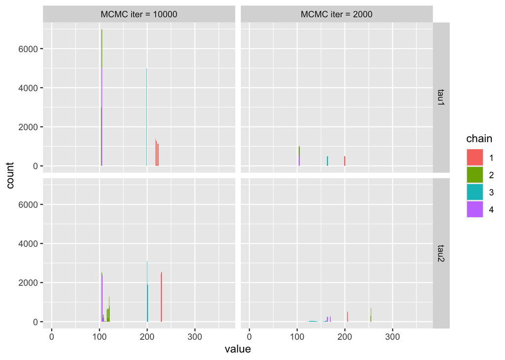

```r
samples2_mcmc_long |>
  filter(name %in% c("tau1", "tau2")) |>
  ggplot(aes(x = value, fill = chain)) +
  facet_grid(name ~ mcmc_iter) +
  geom_histogram(binwidth = 1) +
  xlim(0, 366)
```

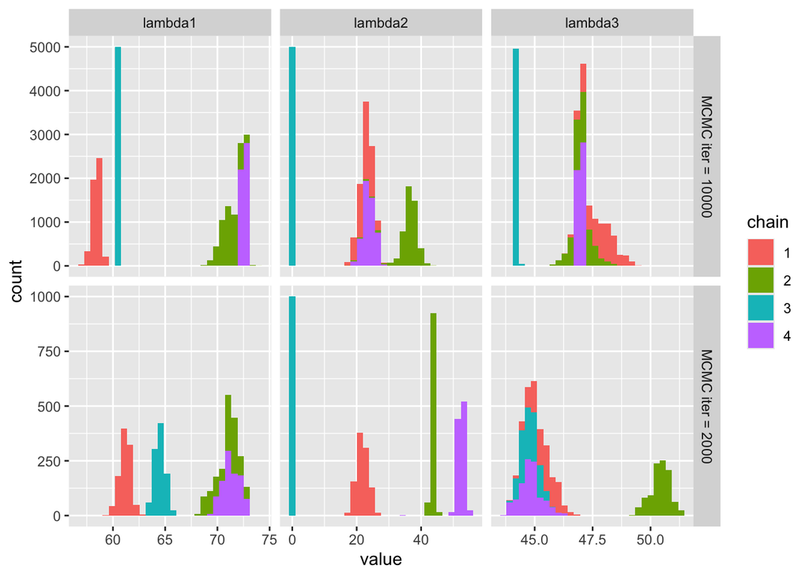

```r
samples2_mcmc_long |>
  filter(!(name %in% c("tau1", "tau2"))) |>
  ggplot(aes(x = value, fill = chain)) +
  facet_grid(mcmc_iter ~ name, scales = "free") +
  geom_histogram()
```